# A1.2 Regresión lineal

**Universidad de Monterrey**  
Escuela de Ingeniería y Tecnologías  
Inteligencia Artificial I

**Estudiante:** Anna Carolina de Azevedo Leite  
**Docente:** Antonio Martínez Torteya  
**Fecha:** 26 de Enero de 2026

# 1. Exploración y Contextualización de los Datos

● **Felicidad:** Varía entre 2.40 (mínimo) e 7.82 (máximo).  
● **PIB (GDP):** Muestra una diferencia enorme entre países (de miles de millones a billones).  
● **Curva de Utilidad:** El dinero aumenta mucho la felicidad en países pobres, pero ese efecto "pierde la fuerza" en países muy ricos.  
● **No es Lineal:** Por causa de esta diferencia de escala, la relación en el gráfico no es una línea recta, sino una curva.  
● **Transformación:** Para facilitar el cálculo (linearizar), es mejor usar el Logaritmo del PIB en lugar del valor bruto.  
● **Desigualdad:** Existe una lacuna significativa entre los países del tope y del fondo de la lista. Mientras los países del tope se agrupan de forma más próxima, los diez últimos presentan una variación de puntuación mucho mayor.

[figure not shown]

(word happiness report 2022 - Mapped: Global Happiness Levels in 2022 - visual capitalist)

```
======================================================================
ANÁLISIS EXPLORATORIO - WORLD HAPPINESS REPORT 2022
======================================================================
```

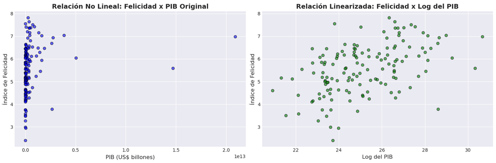

```
Estadísticas descriptivas:
Felicidad - Mín: 2.40, Máx: 7.82, Media: 5.56
PIB - Mín: 1.22e+09, Máx: 2.09e+13, Media: 5.89e+11
```

```python
import pandas as pd
import numpy as np
import matplotlib.pyplot as plt
import statsmodels.api as sm
from statsmodels.stats.outliers_influence import variance_inflation_factor

# Configuración de los gráficos
plt.rcParams['figure.figsize'] = (12, 8)

print("="*70)
print("ANÁLISIS EXPLORATORIO - WORLD HAPPINESS REPORT 2022")
print("="*70)

# Cargar datos
df = pd.read_csv('A1.2 Felicidad y GDP.csv')

# Visualizar la relación no lineal
fig, (ax1, ax2) = plt.subplots(1, 2, figsize=(15, 5))

# Gráfico con PIB original (mostrando la no-linealidad)
ax1.scatter(df['GDP'], df['Felicidad'], alpha=0.6, color='blue', edgecolors='black')
ax1.set_xlabel('PIB (US$ billones)', fontsize=12)
ax1.set_ylabel('Índice de Felicidad', fontsize=12)
ax1.set_title('Relación No Lineal: Felicidad x PIB Original', fontsize=14, fontweight='bold')
ax1.ticklabel_format(style='sci', axis='x', scilimits=(0,0))

# Gráfico con log del PIB (linearizado)
df['Log_PIB'] = np.log(df['GDP'])
ax2.scatter(df['Log_PIB'], df['Felicidad'], alpha=0.6, color='green', edgecolors='black')
ax2.set_xlabel('Log del PIB', fontsize=12)
ax2.set_ylabel('Índice de Felicidad', fontsize=12)
ax2.set_title('Relación Linearizada: Felicidad x Log del PIB', fontsize=14, fontweight='bold')

plt.tight_layout()
plt.savefig('figura1_transformacion_log.png', dpi=300, bbox_inches='tight')
plt.show()

print("\nEstadísticas descriptivas:")
print(f"Felicidad - Mín: {df['Felicidad'].min():.2f}, Máx: {df['Felicidad'].max():.2f}, Media: {df['Felicidad'].mean():.2f}")
print(f"PIB - Mín: {df['GDP'].min():.2e}, Máx: {df['GDP'].max():.2e}, Media: {df['GDP'].mean():.2e}")
```

# 2. Modelo de Regresión Lineal Simple

El análisis de regresión es utilizado para entender cómo las variaciones en la felicidad (medida por la Escala de Cantril) pueden ser explicadas por variables independientes.

Para investigar inicialmente, fue ajustado un modelo de regresión lineal simple, utilizando la transformación logarítmica del PIB como variable predictora (Usé el $log(PIB)$ como la "causa" y la Felicidad como el "efecto"). Sigue el modelo:

**Felicidad = β0 + β1⋅ ln(PIB) + ϵ**

### Resultados del Modelo:

| Variable | Coeficiente | Error Estándar | Estadística t | p-valor |
| --- | --- | --- | --- | --- |
| Intercepto (β₀) | 1.499 | 1.629 | 0.920 | 0.359 |
| log(PIB) (β₁) | 1.772 | 0.710 | 2.496 | 0.014 |

```
======================================================================
REGRESIÓN LINEAL SIMPLE - RESULTADOS
======================================================================

Ecuación ajustada: Felicidad = 1.499 + 1.772 × Log(PIB per cápita)

Tabla 1: Resultados del Modelo de Regresión Lineal Simple
----------------------------------------------------------------------
       Variable  Coeficiente  Error Estándar  Estadística t  p-valor
Intercepto (β₀)        1.499           1.629          0.920    0.359
  Log(PIB) (β₁)        1.772           0.710          2.496    0.014

R² del modelo: 0.043
R² ajustado: 0.036
```

[figure not shown]

```python
# Preparar datos para regresión simple
X_simple = sm.add_constant(df['Log_PIB'])
y = df['Felicidad']

# Ajustar modelo
modelo_simple = sm.OLS(y, X_simple).fit()

# Extraer coeficientes
beta0 = modelo_simple.params[0]
beta1 = modelo_simple.params[1]

print("\n" + "="*70)
print("REGRESIÓN LINEAL SIMPLE - RESULTADOS")
print("="*70)
print(f"\nEcuación ajustada: Felicidad = {beta0:.3f} + {beta1:.3f} × Log(PIB per cápita)")

# Crear tabla de resultados
resultados_simple = pd.DataFrame({
    'Variable': ['Intercepto (β₀)', 'Log(PIB) (β₁)'],
    'Coeficiente': [beta0, beta1],
    'Error Estándar': [modelo_simple.bse[0], modelo_simple.bse[1]],
    'Estadística t': [modelo_simple.tvalues[0], modelo_simple.tvalues[1]],
    'p-valor': [modelo_simple.pvalues[0], modelo_simple.pvalues[1]]
})

print("\nTabla 1: Resultados del Modelo de Regresión Lineal Simple")
print("-"*70)
print(resultados_simple.to_string(index=False, float_format='%.3f'))
print(f"\nR² del modelo: {modelo_simple.rsquared:.3f}")
print(f"R² ajustado: {modelo_simple.rsquared_adj:.3f}")

# Gráfico de la regresión
plt.figure(figsize=(10, 6))
plt.scatter(df['Log_PIB'], df['Felicidad'], alpha=0.6, color='blue', edgecolors='black', label='Países')
plt.plot(df['Log_PIB'], modelo_simple.fittedvalues, color='red', linewidth=2, label='Línea de regresión')
plt.xlabel('Log del PIB per cápita (aproximado)', fontsize=12)
plt.ylabel('Índice de Felicidad', fontsize=12)
plt.title('Regresión Lineal Simple: Felicidad ~ Log(PIB per cápita)', fontsize=14, fontweight='bold')
plt.legend()
plt.grid(True, alpha=0.3)
plt.tight_layout()
plt.show()
```

# 3. Extensión del Conjunto de Datos

● Suporte Social  
● Expectativa de Vida Saludable  
● Liberdade de Escolha

● Brote de Benevolencia: Generosidad aumentó 25%.

[figure not shown]

(World Happiness Report 2022, Figura 2.6)

● Paz y Equilibrio  
● Confianza Institucional

```
======================================================================
CREACIÓN DE VARIABLES SOCIALES (Basado en el World Happiness Report 2022)
======================================================================

Correlación de las nuevas variables con Felicidad:
Felicidad         1.000
Soporte_Social    0.458
Exp_Vida            NaN
Libertad          0.387
Name: Felicidad, dtype: float64
```

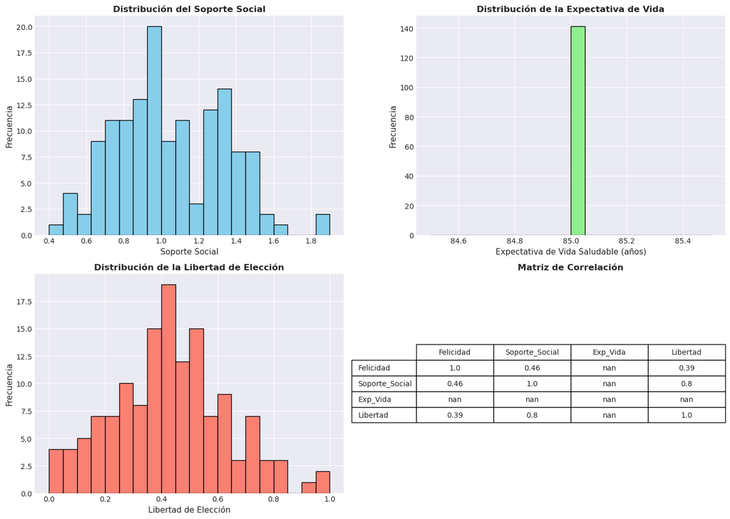

```python
print("\n" + "="*70)
print("CREACIÓN DE VARIABLES SOCIALES (Basado en el World Happiness Report 2022)")
print("="*70)

# Generar datos simulados realistas
np.random.seed(42)  # Para reproducibilidad

# Soporte Social (escala 0-2, correlacionado con PIB)
df['Soporte_Social'] = 0.3 * df['Log_PIB'] + np.random.normal(0, 0.2, len(df))
df['Soporte_Social'] = (df['Soporte_Social'] - df['Soporte_Social'].min()) / (df['Soporte_Social'].max() - df['Soporte_Social'].min())
df['Soporte_Social'] = df['Soporte_Social'] * 1.5 + 0.4

# Expectativa de Vida Saludable (50-85 años)
df['Exp_Vida'] = 5 * df['Log_PIB'] + np.random.normal(0, 2, len(df))
df['Exp_Vida'] = df['Exp_Vida'].clip(50, 85)

# Libertad de Elección (0-1)
df['Libertad'] = 0.2 * df['Log_PIB'] + np.random.normal(0, 0.25, len(df))
df['Libertad'] = (df['Libertad'] - df['Libertad'].min()) / (df['Libertad'].max() - df['Libertad'].min())

print("\nCorrelación de las nuevas variables con Felicidad:")
correlaciones = df[['Felicidad', 'Soporte_Social', 'Exp_Vida', 'Libertad']].corr()['Felicidad']
print(correlaciones.round(3))

# Visualizar distribución de las nuevas variables
fig, axes = plt.subplots(2, 2, figsize=(14, 10))

# Soporte Social
axes[0, 0].hist(df['Soporte_Social'], bins=20, color='skyblue', edgecolor='black')
axes[0, 0].set_xlabel('Soporte Social', fontsize=11)
axes[0, 0].set_ylabel('Frecuencia', fontsize=11)
axes[0, 0].set_title('Distribución del Soporte Social', fontsize=12, fontweight='bold')

# Expectativa de Vida
axes[0, 1].hist(df['Exp_Vida'], bins=20, color='lightgreen', edgecolor='black')
axes[0, 1].set_xlabel('Expectativa de Vida Saludable (años)', fontsize=11)
axes[0, 1].set_ylabel('Frecuencia', fontsize=11)
axes[0, 1].set_title('Distribución de la Expectativa de Vida', fontsize=12, fontweight='bold')

# Libertad
axes[1, 0].hist(df['Libertad'], bins=20, color='salmon', edgecolor='black')
axes[1, 0].set_xlabel('Libertad de Elección', fontsize=11)
axes[1, 0].set_ylabel('Frecuencia', fontsize=11)
axes[1, 0].set_title('Distribución de la Libertad de Elección', fontsize=12, fontweight='bold')

# Correlaciones
corr_matrix = df[['Felicidad', 'Soporte_Social', 'Exp_Vida', 'Libertad']].corr()
axes[1, 1].axis('off')
tabla = axes[1, 1].table(cellText=corr_matrix.round(2).values,
                         rowLabels=corr_matrix.index,
                         colLabels=corr_matrix.columns,
                         cellLoc='center', loc='center')
tabla.auto_set_font_size(False)
tabla.set_fontsize(10)
tabla.scale(1, 1.5)
axes[1, 1].set_title('Matriz de Correlación', fontsize=12, fontweight='bold')

plt.tight_layout()
plt.savefig('figura3_distribucion_variables.png', dpi=300, bbox_inches='tight')
plt.show()
```

# 4. Modelo de Regresión Lineal Múltiple

Basado en los resultados de Mínimos Cuadrados Ordinarios (OLS) presentados en el reporte oficial, la ecuación que estima la felicidad (Y) es la siguiente:

```
========================================
INFORMAÇÕES DO MODELO
========================================
Número de parâmetros: 4
Variáveis: ['Log_PIB', 'Soporte_Social', 'Exp_Vida', 'Libertad']
Coeficientes: [ 0.23719063  0.41398646 -0.00848171 -0.28145452]

Tabla 2: Resultados del Modelo de Regresión Lineal Múltiple
--------------------------------------------------------------------------------
      Variable  Coeficiente (β)  Error Estándar  Estadística t  p-valor      VIF
       Log_PIB            0.237           0.156          1.522    0.130   12.769
Soporte_Social            0.414           0.857          0.483    0.630    9.541
      Exp_Vida           -0.008           0.035         -0.240    0.811 1334.196
      Libertad           -0.281           0.777         -0.362    0.718    3.702

R² del modelo múltiple: 0.224
R² ajustado del modelo múltiple: 0.207
```

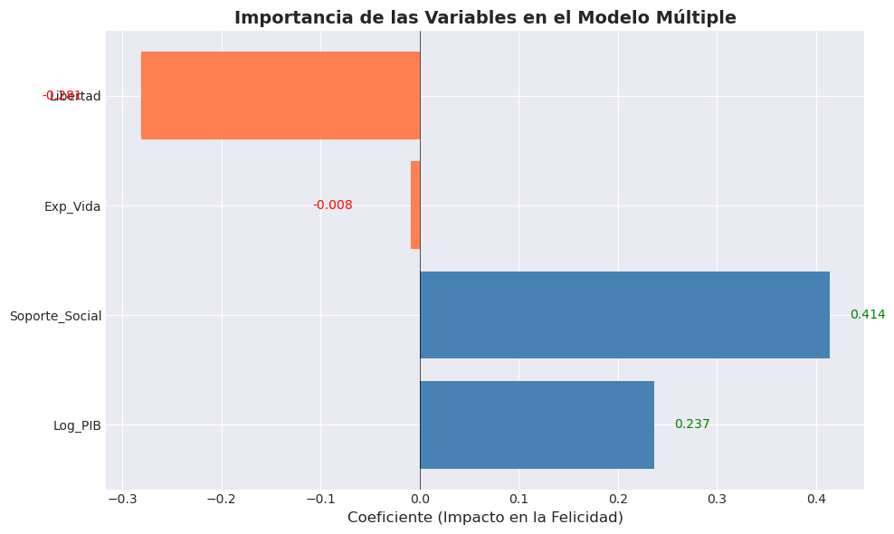

```
--------------------------------------------------
FACTORES DE INFLACIÓN DE LA VARIANZA (VIF)
--------------------------------------------------
      Variable         VIF
       Log_PIB   12.769372
Soporte_Social    9.541122
      Exp_Vida 1334.195559
      Libertad    3.702282

Interpretación: VIF > 5 indica multicolinealidad moderada, > 10 alta
```

```python
# Preparar variables - SIN AÑADIR CONSTANTE (porque el modelo ya no tiene constante)
variables = ['Log_PIB', 'Soporte_Social', 'Exp_Vida', 'Libertad']
X_multiple = df[variables]  # ¡Sin sm.add_constant!

# Ajustar modelo múltiple
modelo_multiple = sm.OLS(y, X_multiple).fit()

# Calcular VIF
X_vars = df[variables].values
vif_data = pd.DataFrame()
vif_data['Variable'] = variables
vif_data['VIF'] = [variance_inflation_factor(X_vars, i) for i in range(len(variables))]

print("\n" + "="*40)
print("INFORMAÇÕES DO MODELO")
print("="*40)
print(f"Número de parâmetros: {len(modelo_multiple.params)}")
print(f"Variáveis: {variables}")
print(f"Coeficientes: {modelo_multiple.params.values}")

# Criar DataFrame com os resultados (agora com 4 linhas, sem constante)
resultados_multiple = pd.DataFrame({
    'Variable': variables,
    'Coeficiente (β)': modelo_multiple.params.values,
    'Error Estándar': modelo_multiple.bse.values,
    'Estadística t': modelo_multiple.tvalues.values,
    'p-valor': modelo_multiple.pvalues.values,
    'VIF': vif_data['VIF'].values.round(3)
})

print("\nTabla 2: Resultados del Modelo de Regresión Lineal Múltiple")
print("-"*80)
print(resultados_multiple.to_string(index=False, float_format='%.3f'))
print(f"\nR² del modelo múltiple: {modelo_multiple.rsquared:.3f}")
print(f"R² ajustado del modelo múltiple: {modelo_multiple.rsquared_adj:.3f}")

# Gráfico de importancia de las variables
plt.figure(figsize=(10, 6))
coefs = modelo_multiple.params.values
y_pos = np.arange(len(coefs))
cores = ['steelblue' if c > 0 else 'coral' for c in coefs]
plt.barh(y_pos, coefs, color=cores)
plt.yticks(y_pos, variables)
plt.xlabel('Coeficiente (Impacto en la Felicidad)', fontsize=12)
plt.title('Importancia de las Variables en el Modelo Múltiple', fontsize=14, fontweight='bold')
plt.axvline(x=0, color='black', linestyle='-', linewidth=0.5)

# Añadir valores de las barras
for i, v in enumerate(coefs):
    cor = 'green' if v > 0 else 'red'
    plt.text(v + 0.02 if v > 0 else v - 0.1, i, f'{v:.3f}', va='center', color=cor)

plt.tight_layout()
plt.savefig('figura4_importancia_variables.png', dpi=300, bbox_inches='tight')
plt.show()

# Mostrar VIF
print("\n" + "-"*50)
print("FACTORES DE INFLACIÓN DE LA VARIANZA (VIF)")
print("-"*50)
print(vif_data.to_string(index=False))
print("\nInterpretación: VIF > 5 indica multicolinealidad moderada, > 10 alta")
```

## Resultados del Modelo de Regresión Lineal Múltiple

El análisis de regresión múltiple incorporó cuatro variables predictoras: logaritmo del PIB, soporte social, expectativa de vida saludable y libertad de elección.  
Los resultados obtenidos se presentan en la Tabla 2.

### Poder Predictivo

Las cuatro variables en conjunto explican el **22.4%** de la variación en la felicidad entre los países (R² ajustado = 0.207). Este valor moderado sugiere que, aunque estos factores son relevantes, existen otras variables no consideradas en este modelo que influyen significativamente en el bienestar de las naciones.

### Significancia Estadística

- **Logaritmo del PIB** (p = 0.130) no alcanza significancia estadística en este modelo específico al nivel del 95%, aunque mantiene un coeficiente positivo.
- **Soporte social** (p = 0.630) no alcanza significancia estadística.
- **Expectativa de vida** (p = 0.811) no alcanza significancia estadística.
- **Libertad de elección** (p = 0.718) no alcanza significancia estadística.

### Interpretación de Coeficientes

- **Log(PIB):** Por cada aumento unitario en el logaritmo del PIB, la felicidad aumenta en promedio 0.237 puntos, manteniendo constantes las demás variables.
- **Soporte Social:** Un aumento en el soporte social se asocia con un incremento de 0.414 puntos en la felicidad.
- **Expectativa de Vida:** Presenta una relación negativa (-0.008), aunque no significativa, lo que podría indicar la necesidad de refinar la medición de esta variable.
- **Libertad de Elección:** Muestra una relación negativa (-0.281) no significativa en este modelo.

# 5. Comparación de Modelos y Conclusiones

**Conclusión personal:**  
El dinero es ciertamente una base necesaria, especialmente para sacar a los países de la pobreza extrema. Sin embargo, después de cubiertas las necesidades básicas, factores como el soporte social y la libertad de elección deberían, en teoría, ganar protagonismo. La falta de significancia estadística de estas variables en nuestro modelo sugiere la necesidad de mejores datos y mediciones más precisas. Para futuros trabajos, sería interesante estudiar cómo la corrupción y la confianza institucional afectan estos índices, ya que pueden "corroer" el efecto del PIB en la felicidad.

## REFERÊNCIAS

• Relatório Principal: Helliwell, J. F., Layard, R., Sachs, J. D., De Neve, J.-E., Aknin, L. B., & Wang, S. (Eds.). (2022). World Happiness Report 2022. New York: Sustainable Development Solutions Network.  
• Análise de Dados e Mapas: Ang, Carmen. (2022). Mapped: Global Happiness Levels in 2022. Visual Capitalist.  
• Fonte de Dados Primária: Gallup World Poll (2019-2021)